# MATH 241: Homework 04

Write Your Name Here

Due Friday 2015/4/17 5:00pm on Moodle

Please indicate

- Approximately how much time you spent on this homework:
- What, if anything, gave you an exceeding amount of trouble? By exceeding I mean above and beyond run-of-the-mill difficulties when learning new things.

## Question 1:

Consider the breast cancer from HW02. Plot, using the `ww` shapefiles provided in Lecture 20, three maps:

- A map of overall breast cancer incidence rate for each census tract: $\frac{y_i}{N_i}$ where for each census tract $i=1,\ldots,n$
  - $y_i$ is the total number of cases
  - $N_i$ is the total number of people
- A map of the median income **quintiles**. i.e. your map should be a [chrolopleth map](http://2.bp.blogspot.com/_Vod56KuZXlk/S9IdL4yW14I/AAAAAAAAAFc/jHIE6fPuQvM/s1600/standardized+c+map.PNG) involving only 5 colors.
- A map of that gives a sense of census tracts with high and low breast cancer incidence rates *while taking income into account*. The approach I’m thinking of is rather simple mathematically, but requires some thought to come up with.

Notes:

- You should use the solutions from HW02.
- Do not import the shapefiles using the code from Lecture 20, but rather the `readOGR()` function from Lectures 23 and 25.

## Question 2:

Download the results of the 2000 election from the [School of Public Affairs at American University in DC](http://www.american.edu/spa/ccps/Data-Sets.cfm) and create two maps involving only the lower 48 states that show:

- The proportion of people who voted for Bush at a **state** level
- The proportion of people who voted for Bush at a **county** level

where

- Counties are filled with red when they tend to favor Bush
- Counties tracts are filled with blue when they tend to not favor Bush
- Counties tracts are filled with purple when they tend to be split

Then answer the following questions:

1. Comment on the biggest differences when changing from “county” resolution to “state” resolution.
2. Comment on how the maps align with the idea of the [Nine Nations of North America](http://en.wikipedia.org/wiki/The_Nine_Nations_of_North_America)
3. Which states exhibit the greatest **within state heterogeneity** in voting? Come up with a mathematical justification.

Notes:

- Hint: `scale_fill_gradient2(name="", low="blue", high="red", mid="purple")` for the appropriate “mid” point. See the ggplot2 webpage for this command for inspiration.
- I believe the county map is from 2010, whereas the election data is from 2000, as such certain census tracts will not match up. The number is not that large.
- [Counties in Virginia](http://en.wikipedia.org/wiki/List_of_counties_in_Virginia)
- The following code should help:

```r
# This function eliminates all non-alphanumeric characters and spaces and
# converts all text to lower case.
clean.text <- function(text){
  text <- gsub("[^[:alnum:]]", "", text)
  text <- gsub(" ", "", text)
  text <- tolower(text)
  return(text)
}
clean.text("HeLLO wOrLd.")
```

```
## [1] "helloworld"
```

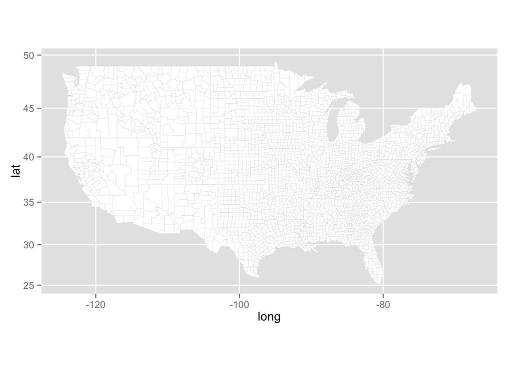

```r
# State and county map of US in 2010
US.state <- map_data("state") %>% tbl_df()
US.county <- map_data("county") %>% tbl_df()
ggplot(US.county, aes(x=long, y=lat, group=group)) +
  geom_polygon(fill="white") +
  geom_path(col="black", size=0.01) +
  coord_map()
```

## Question 3:

The Chief of the Portland Police is tired of reading through pages of crime reports and wants an interactive tool to visualize where different crimes occured during the years 2004 and 2013. Obtain crime data for Portland for years 2004 through 2013 from the [CivicApps](http://www.civicapps.org/datasets) site, create (in a separate `.Rmd` file) an appropriate Shiny app, and publish it online. Post the hyperlink [here](http://canadiens.nhl.com/?navid=nav-teamnav-mtl).

Your Shiny app should take in two inputs. Think carefully which is the best way to have users input these:

- A way to select the year: 2004, 2005, …, 2013, or all
- Select the crime

Using this app, answer the following questions:

- What crimes appear to have unequal spatial enforcement?
- What crimes are the most related to each other?
- If the Portland Police receives a large grant from the state government to fight crime, what do you think it should do?